# QRM II Graded Assignment (6)

Period 1, 2026

Sophie Thoolen, Clemence van Gils, Benthe Tromp en Roos Bakker

11-10-2026

# Introduction

This assignment is to be completed in groups of 4-5. Further, all students in your group need to be assigned to the same R tutorial group (Friday’s tutorial). You can sign yourself up for a group on Canvas. Please do so You can use the Discussion Board in Canvas if you do not have a group yet or if your group is incomplete.

The assignment has 5 parts, and each part corresponds to the course material of that week (with the exclusion of week 6, for which there is no R programming material).

You are supposed to hand in these assignments on Canvas at the following dates:

- **Deadline 1** *Sunday September 27th, at 23:59pm*: you are supposed to hand in weeks 1, 2, and 3 of this assignment. This will determine 18% of your overall course grade
- **Deadline 2** *Sunday October 11th, at 23:59pm*: you are supposed to hand in weeks 4, and 5 of this assignment. This will determine 12% of your overall course grade

The R tutorials (each Friday) will consist of two halves. During the first half, you will discuss the tutorial exercises. These can be downloaded separately from Canvas. During the second half, you can work on this graded assignment within your own group. The purpose is that you find out how to work with R for doing statistical analyses by yourself. The tutorial exercises are meant to teach you basic commands to get you started, but to answer the problem sets in this assignment, you might need to research your own solutions, and use functions and commands not described in the tutorial exercises. Learning how to solve your own research problems is integral part of learning R. When you and your group get stuck on how to approach an exercise, the hierarchy in finding your way is as follows:

- use the concepts from the tutorial exercises;
- use the cheat sheets available on Canvas;
- use Google, YouTube, StackOverflow, or another website;
- ask the teacher.

The use of generative AI is permitted and may result in a grade of 0. See the AI protocol in the course manual for details.

To answer the assignment, you can simply fill out this R markdown document. There are designated places which you can fill with R code. There are also designated spaces for you to answer each question. Often, the structure of an answer will be as follows. First, you type the R code in the designated box. This will show how you analyzed the data to get the answer to the question. Below the box for the R code, you will then summarize your answer to the question, i.e. what are the conclusions that you draw from the data analysis?

When handing in, you are supposed to submit this .Rmd file, and a knitted version of this document. You can knit this document to pdf, word, or html. Knitting to pdf requires you to have a .tex distribution installed on your computer. Knitting to Word requires you to have Word installed.

The exercises are designed such that you should be able to finish the majority of them during the tutorial each week. If you are not able to finish them fully during that time, you are expected to work on it in your own time using the computers on campus or your own device. It is best to meet as a group in-person when working together. If you want to work remotely, github is a good platform to guarantee smooth collaboration. Alternatively, you can email this .Rmd file back and forth to one another as a group, but this is not recommended as it is more cumbersome.

We encourage you to keep your code blocks, printing statements, and final answers, as short as possible. In any case, there is a page limit of 6 pages per week, which encompasses the total length of this document which consists of the questions, your coding lines, and your answers. When your answers to questions of the respective week exceed this page limit, they will not be graded, resulting in zero points.

# Week 1

1. Find the dataset “movies4.tsv” on Canvas. Describe your data set: How many observations does it have. How many variables are there? How many subjects? What consists of a subject?

```r
#WRITE YOUR CODE HERE
movies <- read.delim("movies4.tsv", sep = "\t", header = TRUE)

#number observations
nrow(movies)
```

```
## [1] 808
```

```r
#number of variables
ncol(movies)
```

```
## [1] 19
```

```r
head(movies)
```

|  | index | budget | keywords | original_language | title | popularity | release_date | revenue | runtime | vote_average | vote_count | genre | release_year | release_month | release_day | first_actor | first_actor_gender | director_first_name | director_gender |
| --- | --- | --- | --- | --- | --- | --- | --- | --- | --- | --- | --- | --- | --- | --- | --- | --- | --- | --- | --- |
| 1 | 2256 | 0.0e+00 | NA | en | The Oogieloves in the Big Balloon Adventure | 0.285760 | 2012-08-29 | 0 | 88 | 2.2 | 8 | Family | 2012 | 8 | 29 | Christopher Lloyd | male | Matthew | male |
| 2 | 2473 | 1.5e+07 | barcelona spain menage a trois author | en | Vicky Cristina Barcelona | 32.758254 | 2008-08-15 | 96408652 | 96 | 6.7 | 1020 | Drama | 2008 | 8 | 15 | Scarlett Johansson | female | Woody | male |
| 3 | 1514 | 3.2e+07 | gunslinger revenge prairie shootout pistol | en | The Quick and the Dead | 16.473355 | 1995-02-09 | 18552460 | 107 | 6.3 | 427 | Action | 1995 | 2 | 9 | Sharon Stone | female | Sam | male |
| 4 | 1512 | 3.2e+07 | robbery double life dual identity small town indiana | en | A History of Violence | 34.628738 | 2005-09-23 | 60740827 | 96 | 6.9 | 832 | Drama | 2005 | 9 | 23 | Viggo Mortensen | male | David | male |
| 5 | 395 | 8.5e+07 | holiday london england film making christmas party country house | en | The Holiday | 44.967453 | 2006-12-08 | 194168700 | 136 | 6.7 | 1225 | Comedy | 2006 | 12 | 8 | Cameron Diaz | male | Nancy | female |
| 6 | 3156 | 0.0e+00 | 1970s human animal relationship australia grief search | en | Red Dog | 5.499412 | 2011-08-04 | 0 | 92 | 7.1 | 83 | Drama | 2011 | 8 | 4 | Josh Lucas | male | Kriv | NA |

```r
str(movies)
```

```
## 'data.frame':    808 obs. of  19 variables:
##  $ index              : int  2256 2473 1514 1512 395 3156 4753 4590 1665 2714 ...
##  $ budget             : num  0.0 1.5e+07 3.2e+07 3.2e+07 8.5e+07 0.0 6.0e+04 0.0 0.0 1.4e+07 ...
##  $ keywords           : chr  NA "barcelona spain menage a trois author" "gunslinger revenge prairie shootout pistol" "robbery double life dual identity small town indiana" ...
##  $ original_language  : chr  "en" "en" "en" "en" ...
##  $ title              : chr  "The Oogieloves in the Big Balloon Adventure" "Vicky Cristina Barcelona" "The Quick and the Dead" "A History of Violence" ...
##  $ popularity         : num  0.286 32.758 16.473 34.629 44.967 ...
##  $ release_date       : chr  "2012-08-29" "2008-08-15" "1995-02-09" "2005-09-23" ...
##  $ revenue            : num  0.00 9.64e+07 1.86e+07 6.07e+07 1.94e+08 ...
##  $ runtime            : int  88 96 107 96 136 92 93 97 138 149 ...
##  $ vote_average       : num  2.2 6.7 6.3 6.9 6.7 7.1 5.1 5.6 6.7 6.1 ...
##  $ vote_count         : int  8 1020 427 832 1225 83 6 4 144 86 ...
##  $ genre              : chr  "Family" "Drama" "Action" "Drama" ...
##  $ release_year       : int  2012 2008 1995 2005 2006 2011 2012 2004 2004 2011 ...
##  $ release_month      : int  8 8 2 9 12 8 10 9 9 9 ...
##  $ release_day        : int  29 15 9 23 8 4 13 23 3 30 ...
##  $ first_actor        : chr  "Christopher Lloyd" "Scarlett Johansson" "Sharon Stone" "Viggo Mortensen" ...
##  $ first_actor_gender : chr  "male" "female" "female" "male" ...
##  $ director_first_name: chr  "Matthew" "Woody" "Sam" "David" ...
##  $ director_gender    : chr  "male" "male" "male" "male" ...
```

```r
summary (movies)
```

```
##      index          budget               keywords   original_language
##  Min.   :   1   Min.   :        0   Length   :808   Length   :808
##  1st Qu.:1160   1st Qu.:       22   N.unique :702   N.unique : 18
##  Median :2342   Median : 15000000   N.blank  :  0   N.blank  :  0
##  Mean   :2353   Mean   : 29842216   Min.nchar:  4   Min.nchar:  2
##  3rd Qu.:3510   3rd Qu.: 40000000   Max.nchar:106   Max.nchar:  2
##  Max.   :4801   Max.   :300000000   NAs      : 87
##        title       popularity           release_date    revenue
##  Length   :808   Min.   :2.388e-03   Length   :808   Min.   :0.000e+00
##  N.unique :808   1st Qu.:4.898e+00   N.unique :745   1st Qu.:0.000e+00
##  N.blank  :  0   Median :1.270e+01   N.blank  :  0   Median :1.456e+07
##  Min.nchar:  2   Mean   :2.032e+01   Min.nchar: 10   Mean   :8.273e+07
##  Max.nchar: 59   3rd Qu.:2.656e+01   Max.nchar: 10   3rd Qu.:8.521e+07
##                  Max.   :2.020e+02                   Max.   :1.520e+09
##     runtime       vote_average      vote_count             genre
##  Min.   :  0.0   Min.   : 0.000   Min.   :    0.00   Length   :808
##  1st Qu.: 93.0   1st Qu.: 5.500   1st Qu.:   54.75   N.unique : 13
##  Median :103.0   Median : 6.200   Median :  240.00   N.blank  :  0
##  Mean   :105.4   Mean   : 6.039   Mean   :  688.58   Min.nchar:  5
##  3rd Qu.:116.0   3rd Qu.: 6.800   3rd Qu.:  776.50   Max.nchar: 11
##  Max.   :192.0   Max.   :10.000   Max.   :12002.00   NAs      :  3
##   release_year  release_month     release_day       first_actor
##  Min.   :1990   Min.   : 1.000   Min.   : 1.00   Length   :808
##  1st Qu.:2001   1st Qu.: 4.000   1st Qu.: 8.00   N.unique :555
##  Median :2007   Median : 7.000   Median :15.00   N.blank  :  0
##  Mean   :2006   Mean   : 6.708   Mean   :15.33   Min.nchar:  5
##  3rd Qu.:2011   3rd Qu.: 9.000   3rd Qu.:23.00   Max.nchar: 23
##  Max.   :2016   Max.   :12.000   Max.   :31.00   NAs      :  6
##  first_actor_gender director_first_name  director_gender
##  Length   :808      Length   :808       Length   :808
##  N.unique :  2      N.unique :357       N.unique :  2
##  N.blank  :  0      N.blank  :  0       N.blank  :  0
##  Min.nchar:  4      Min.nchar:  2       Min.nchar:  4
##  Max.nchar:  6      Max.nchar: 18       Max.nchar:  6
##  NAs      : 34      NAs      :  4       NAs      : 43
```

```r
#number of subjects
nrow(movies)
```

```
## [1] 808
```

```r
##checked if all observations are different
length(unique(movies$title))
```

```
## [1] 808
```

**Your Answer:**

The data set contains 808 observations and 19 variables. A subject is a individual movie and each observation corresponds to a movie, identified by the variable ‘title’. Since there is no recurrence of the same movie name, the number of subjects is equal to the number of observations. (which is 808)

2. Which of the following types of variables are present in your data set? (i) nominal; (ii) ordinal; (iii); continuous; (iv) discrete. If present, name one example of such a variable present in your data set.

```r
#WRITE YOUR CODE HERE
##checking the variables
str(movies)
```

```
## 'data.frame':    808 obs. of  19 variables:
##  $ index              : int  2256 2473 1514 1512 395 3156 4753 4590 1665 2714 ...
##  $ budget             : num  0.0 1.5e+07 3.2e+07 3.2e+07 8.5e+07 0.0 6.0e+04 0.0 0.0 1.4e+07 ...
##  $ keywords           : chr  NA "barcelona spain menage a trois author" "gunslinger revenge prairie shootout pistol" "robbery double life dual identity small town indiana" ...
##  $ original_language  : chr  "en" "en" "en" "en" ...
##  $ title              : chr  "The Oogieloves in the Big Balloon Adventure" "Vicky Cristina Barcelona" "The Quick and the Dead" "A History of Violence" ...
##  $ popularity         : num  0.286 32.758 16.473 34.629 44.967 ...
##  $ release_date       : chr  "2012-08-29" "2008-08-15" "1995-02-09" "2005-09-23" ...
##  $ revenue            : num  0.00 9.64e+07 1.86e+07 6.07e+07 1.94e+08 ...
##  $ runtime            : int  88 96 107 96 136 92 93 97 138 149 ...
##  $ vote_average       : num  2.2 6.7 6.3 6.9 6.7 7.1 5.1 5.6 6.7 6.1 ...
##  $ vote_count         : int  8 1020 427 832 1225 83 6 4 144 86 ...
##  $ genre              : chr  "Family" "Drama" "Action" "Drama" ...
##  $ release_year       : int  2012 2008 1995 2005 2006 2011 2012 2004 2004 2011 ...
##  $ release_month      : int  8 8 2 9 12 8 10 9 9 9 ...
##  $ release_day        : int  29 15 9 23 8 4 13 23 3 30 ...
##  $ first_actor        : chr  "Christopher Lloyd" "Scarlett Johansson" "Sharon Stone" "Viggo Mortensen" ...
##  $ first_actor_gender : chr  "male" "female" "female" "male" ...
##  $ director_first_name: chr  "Matthew" "Woody" "Sam" "David" ...
##  $ director_gender    : chr  "male" "male" "male" "male" ...
```

**Your Answer:**

The following types of variables are present in this data set:

- Nominal: Yes, for example the variable genre or language which are organized by category without a specific order.
- Ordinal: Yes, for example the variable release_month (stored as a number but represents a month). This gives it a way to be ordered by category but it doesn’t carry the same quantitative meaning as the release_year, since its more about order instead of an exact measurable gap.
- Continuous: Yes, for example the variable budget (which displays the amount of money, with decimals).
- Discrete: Yes, for example with the variable vote_count (which shows a variable that is countable, in this case the number of votes.)
3. A movie studio wants to know which types of movies give maximal revenue. Perform the following steps to provide the movie studio with an analysis which corresponds to their request:
1. Summarize the variable revenue and report its mean, median, maximum, and minimum.
2. Which movie has the highest revenue in your data set and how much is this revenue. Which movie has the lowest and how much is its revenue? If multiple movies have the exact same highest or lowest revenue, give only one example.
3. Create a histogram of the variable revenue. Make sure it has an appropriate title, and appropriate titles and labels for the x- and y-axis. Describe the shape of the histogram. What does this tell you about the nature of making money in the movies industry?
4. Add a new variable to your data set: the log of revenue. When creating this variable, what happens to movies for which revenue is zero? What then happens when you calculate the mean of log revenue?
5. For movies that have a revenue of zero, replace log of revenue with “NA”. What is now the mean of log of revenue? Create a histogram for log revenue, again with an appropriate title, x- and y-axis labels. Describe the shape of this histogram.
6. For the variables revenue and log of revenue calculate their skewness and kurtosis. How do these numbers relate to the shape of the histograms that you estimated under d.) and e.)?

For each step, you should provide first all the code you used to answer the question and then formulate an answer using full sentences.

Each week consists of 1, 2, or 3 subquestions. The total amount of points you can earn per week is 20 points.

*Step a*

```r
#WRITE YOUR CODE HERE
summary(movies$revenue)
```

```
##      Min.   1st Qu.    Median      Mean   3rd Qu.      Max.
## 0.000e+00 0.000e+00 1.456e+07 8.273e+07 8.521e+07 1.520e+09
```

```r
mean(movies$revenue)
```

```
## [1] 82727885
```

```r
median(movies$revenue)
```

```
## [1] 14560504
```

```r
max(movies$revenue)
```

```
## [1] 1519557910
```

```r
min(movies$revenue)
```

```
## [1] 0
```

**Your Answer:** The mean of revenue is $82,727,885 and the median of revenue is $14,560,504. The maximum revenue is $1,519,557,910 and the minimum revenue is $0

*Step b*

```r
#WRITE YOUR CODE HERE
##highest revenue
movies[which.max(movies$revenue), c("title", "revenue")]
```

|  | title | revenue |
| --- | --- | --- |
| 346 | The Avengers | 1519557910 |

```r
##lowest revenue
movies[which.min(movies$revenue), c("title","revenue")]
```

|  | title | revenue |
| --- | --- | --- |
| 1 | The Oogieloves in the Big Balloon Adventure | 0 |

**Your Answer:** The movie which has the highest revenue is “The Avengers” with a revenue of $1,519,557,910. The movie with the lowest revenue is “The Oogieloves in the Big Balloon Adventure” which has a revenue of $0.

*Step c*

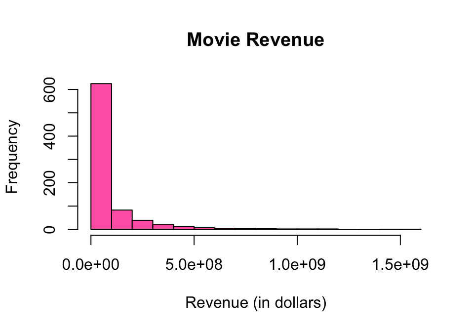

```r
#WRITE YOUR CODE HERE
hist(movies$revenue,
     main= "Movie Revenue",
     xlab= "Revenue (in dollars)",
     ylab= "Frequency",
     col="hotpink")
```

**Your Answer:** The revenue data is mostly right-skewed since most movies have a low revenue and only a few have a extremely high revenue. This is shown in the histogram with a large bar at the start and which thins out to just a couple movies at the end of the graph. The graph suggests that the revenue is unevenly distributed in the film industry with a big portion of movies earning way less than the big movies, and needing a hit to earn a lot of revenue.

*Step d*

```r
#WRITE YOUR CODE HERE
movies$log_revenue <-log(movies$revenue)

##movies with revenue 0
sum(movies$revenue==0)
```

```
## [1] 257
```

```r
mean(movies$log_revenue)
```

```
## [1] -Inf
```

**Your Answer:** There are 257 movies with a revenue of 0. R gives -Inf as a response since the logarithm of 0 is undefined and approaching a negative infinity. This causes the entire mean to become -Inf because of the presence of these -Inf values (and making it not interpretative).

*Step e*

```r
#WRITE YOUR CODE HERE
movies$log_revenue[movies$revenue==0] <- NA
mean(movies$log_revenue, na.rm=TRUE)
```

```
## [1] 17.27957
```

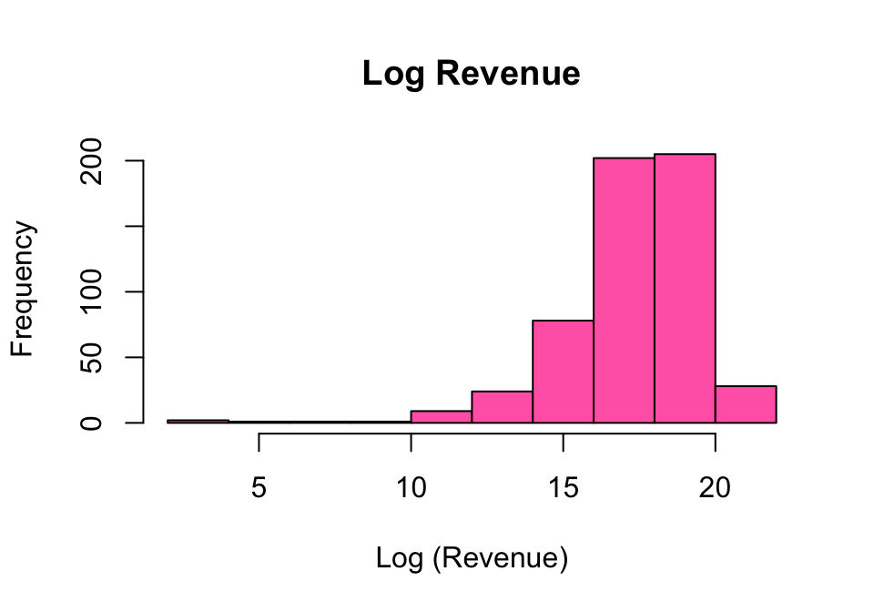

```r
hist(movies$log_revenue,
     main= "Log Revenue",
     xlab= "Log (Revenue)",
     ylab= "Frequency",
     col= "hotpink")
```

**Your Answer:** The mean of the log revenue is now 17.28, after replacing the movies with zero revenue with NA and excluding these from the calculation with na.rm=TRUE. The histogram of the log revenue shows a more symmetric bell shaped distribution in contrast to the more right skewed histogram from step c. Most values are now concentrated around the mean indicating that the log-transformation reduced the extreme skewness.

*Step f*

```r
#WRITE YOUR CODE HERE
#to run this code: install.packages("moments")
library(moments)
skewness(movies$revenue)
```

```
## [1] 3.903008
```

```r
kurtosis(movies$revenue)
```

```
## [1] 22.37797
```

```r
skewness(movies$log_revenue, na.rm=TRUE)
```

```
## [1] -1.955152
```

```r
kurtosis(movies$log_revenue, na.rm=TRUE)
```

```
## [1] 10.94619
```

**Your Answer:**

Revenue has a skewness of 3.90 and a kurtosis of 22.38. Both numbers are higher than expected under a normal distribution (skewness=0, kurtosis ≈ 3), which matches the histogram from step c (most movies earn relatively little, while a couple movies earn far more). This pulls the distribution far to the right and creates a long tail and extreme outliers.

# Week 2

1 Is your dataset movies4.tsv the full population, or is it a sample of a larger population? If the latter, how would you describe the full population?

*Your answer here:*

This data set is a sample of a larger population, not the full population because the set only contains 808 movies which are not all of the movies which are produced in history. The full population would be more like all commercially released films, mostly English from 1990 to 2016, from which data is available.

2 For this question, you will assume that your data set is the full population.

1. What is the mean of the variable vote_average in your data set?
2. Create a new data set, called movies_sample. Make sure that it is a random sample of your data set of 25 movies. What is the mean of vote_average in this random sample? How does it compare to the mean of vote_average in 2a?
3. In a for loop, create 100 different samples of 25 movies, as in b, and estimate the mean within each sample. Save the mean of each sample in a vector called sample_means. So the first position of the vector would have the mean of the first sample, the second position the mean of the second sample, etc. Print the start of this vector.
4. Summarize and make a histogram of sample_means. What is the mean, standard deviation and shape of its distribution?
5. Using the formulas of the *Central Limit Theorem*, give the distribution of the sample mean of vote_average in a sample of 25 movies from your population (including its expected value and standard deviation). How do these values compare to your answers at d.)?

*Step a*

```r
#WRITE YOUR CODE HERE
mean(movies$vote_average)
```

```
## [1] 6.039356
```

**Your Answer:**

Assuming that the data set represents the full population, the population mean of vote_average is 6.04.

*Step b*

```r
#WRITE YOUR CODE HERE
##fixes random number generator, makes the sample reproducible
set.seed(123)
movies_sample <-movies[sample(nrow(movies),25),]
mean(movies_sample$vote_average)
```

```
## [1] 6.016
```

**Your Answer:** A random sample of 25 was drawn with the mean of 6.016 for the vote_average. This is very close to the population mean from step a. The difference of 0.024 reflects the normal sampling variability and wont match the true population mean but will be quite representative for such a small sample.

*Step c*

```r
#WRITE YOUR CODE HERE
##fixes random generator, makes the sample reproducible
set.seed(123)

sample_means <-numeric(100)

for (i in 1:100){
  temp_sample <-movies[sample(nrow(movies),25), ]
  sample_means[i] <- mean(temp_sample$vote_average)
}
head(sample_means)
```

```
## [1] 6.016 6.172 5.856 6.112 6.016 5.696
```

**Your Answer:** With a loop was used to draw 100 samples of 25 movies each and the mean of vote_average was calculated and stored for each sample of the sample_means. The first six values of this vector are 6.016, 6.172,5.856,6.112, 6.016, 5.696.

*Step d*

```r
#WRITE YOUR CODE HERE
summary(sample_means)
```

```
##    Min. 1st Qu.  Median    Mean 3rd Qu.    Max.
##   5.508   5.904   6.038   6.046   6.202   6.608
```

```r
mean(sample_means)
```

```
## [1] 6.04564
```

```r
sd(sample_means)
```

```
## [1] 0.2205852
```

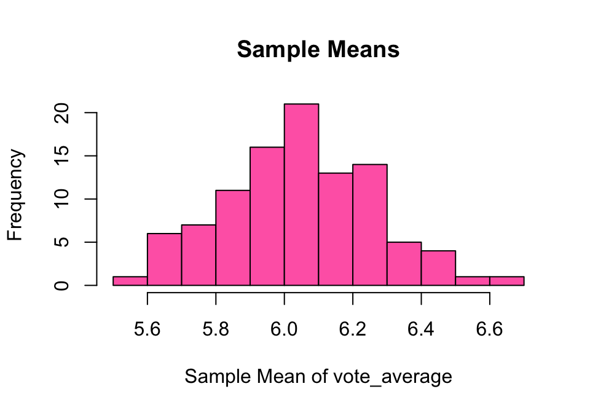

```r
hist(sample_means,
     main = "Sample Means",
     xlab = "Sample Mean of vote_average",
     ylab = "Frequency",
     col = "hotpink")
```

**Your Answer:** The mean of sample_mean is 6.046, which is close to the population mean of vote_average (6.04) found in step a. The standard deviation of sample_means is 0.221, representing the standard error of the sampling distribution. The histogram of sample_means shows an approximately symmetric distribution centered around the population mean.This is consistent with the Central Limit Theorem, which says that the distribution of the sample means becomes more normal as the number of samples increases, even when the underlying variable itself is not perfectly normally distributed.

*Step e*

```r
#WRITE YOUR CODE HERE
population_mean <-mean(movies$vote_average)
population_sd <- sd(movies$vote_average)

n<-25
expected_value <- population_mean
standard_error <-population_sd/ sqrt(n)

expected_value
```

```
## [1] 6.039356
```

```r
standard_error
```

```
## [1] 0.2369204
```

**Your Answer:**

According to the Central Limit Theorem, the sampling distribution of the mean of vote_average for samples of size 25 is around normal (with expected value to the equal population mean (6.039) and a standard deviation (0.237) close to the results found in d (6.046 and 0.221).The small differences can be explained by the number of samples (100 in comparison with infinite number of samples). With more simulated samples, the empirical values would be expected to become even closer to the theoretical CLT predictions.

3. Is there a variable in your data set which you would expect to follow a discrete uniform distribution? Explain, without looking at the data, why you expect this data to be discrete uniform. If the data would indeed follow a discrete uniform distribution, what would you expect the mean and standard deviation of this variable to be? Next, plot a histogram of the variable, and plot an appropriate discrete uniform distribution on top of this histogram. Comment whether the variable indeed follows this expected distribution. If the distribution deviates from the discrete uniform distribution, explain why this is the case.

   ```r
   # theoretical values
   n <- 31
   a <- 1
   b <- 31
   exp_mean <- (a+b) / 2
   exp_sd <- sqrt((n^2 - 1) / 12)

   exp_mean # 16
   ```

   ```
   ## [1] 16
   ```

   ```r
   exp_sd # 8.94
   ```

   ```
   ## [1] 8.944272
   ```

   ```r
   # true mean and standard deviation in the data
   mean(movies$release_day,na.rm = TRUE)
   ```

   ```
   ## [1] 15.33416
   ```

   ```r
   sd(movies$release_day,na.rm = TRUE)
   ```

   ```
   ## [1] 8.563328
   ```

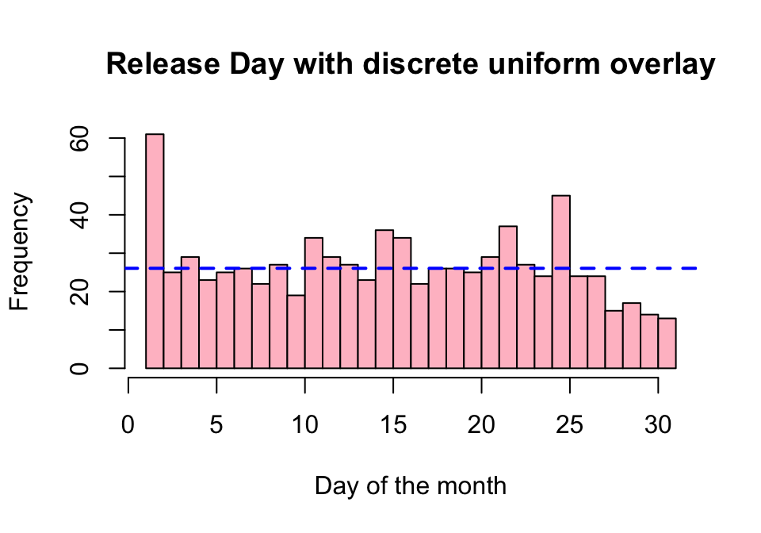

   ```r
   #histogram with discrete uniform overlay
   hist(movies$release_day,
        main= "Release Day with discrete uniform overlay",
        xlab= "Day of the month",
        ylab= "Frequency",
        col="pink",
        breaks= 31)

   expected_freq <- sum(!is.na(movies$release_day))/31
   abline(h=expected_freq,col="blue",lwd=2,lty=2)
   ```

**Your Answer:**

We would expect that the variable release_day follows a discrete uniform distribution. Based on factors (such as season and holiday periods) film studios choose a release date, but there is no reason to assume that a specific date in the month makes a real difference (for example the 18th compared to the 19th). So movies are relatively evenly spread across the days.

If release_day is uniform over 1-31, the expected mean would be (1+31)/2=16, and the expected sd sqrt(31^2 -1)/12 ≈ 8.94. The actual mean and sd are actually very close to these theoretical values (15.33 and 8.56).

However the histogram shows that it is not perfectly uniform, for example day 1 has big spike (61 movies) as well as day 15 and 25 which stand out above the blue line. There also seems to be a decline from day 27 to 31, but that’s not a real deviation since not all months have those days. Only the spikes at day 1, 15 and 25 can be considered as real deviation. Studios likely release movies on more memorable ‘round’ dates for marketing reasons than just spreading release dates randomly. It looks more like a choice, not a random date, while still matching the overall mean and sd from the uniform prediction.

# Week 3

For the next part of the assignment, assume that the movies in your data frame are a random sample of a larger population of movies.

1. Give a 90 percent confidence interval for the variable *revenue*. Interpret the result.

```r
#WRITE YOUR CODE HERE

t.test(movies$revenue, conf.level=0.90)
```

```
##
##  One Sample t-test
##
## data:  movies$revenue
## t = 13.628, df = 807, p-value < 2.2e-16
## alternative hypothesis: true mean is not equal to 0
## 90 percent confidence interval:
##  72731406 92724364
## sample estimates:
## mean of x
##  82727885
```

**Your Answer:**

The 90% confidence interval for the mean of revenue is [$72,731,406 , $92,724,364]. This means that samples of this size (n=808) are drawn repeatedly and for every time a confidence interval is drawn, it would be expected that 90% of these intervals contain the true population mean of revenue. Based on this sample that’s drawn, it can be said with a 90% confidence that the true population mean revenue lies between $72,731,406 and $92,724,364.

2

1. How many movies in your sample were directed by a male director? How many by a female director?
2. Test the null hypothesis that the chance that a movie is being directed by a male or female director is equal. Clearly state your null hypothesis and alternative hypothesis, and your chosen significance level. Use an appropriate R function to test your hypothesis, and state your conclusion. Also give the p-value that corresponds to your test statistic.
3. Recode revenue such that it is measured in millions of dollars. What is the variance of revenue for movies with a male director? What is the variance of revenue for movies with a female director?
4. Assume that the variance of revenue for movies with a male director in your data is the same as the variance for movies with a male director in your population (that is, there is no sampling uncertainty in this estimate). Now, set up a hypothesis test to test for the null hypothesis that the variance of revenue for movies with a female director is equal to the variance for movies with a male director. Clearly state your null hypothesis and alternative hypothesis, and your chosen significance level. Calculate your test statistic and tell how your test statistic is distributed, and state your conclusion. Also give the p-value that corresponds to your test statistic.

*step a*

```r
#WRITE YOUR CODE HERE
table(movies$director_gender)
```

```
##
## female   male
##     80    685
```

**Your Answer:**

This code counts how many times each value (male and female) appears in the director_gender column. The result shows 80 movies with a female director and 685 movies with a male director.

*step b*

```r
#WRITE YOUR CODE HERE
table_gender<-table(movies$director_gender)
print(table_gender)
```

```
##
## female   male
##     80    685
```

```r
class(table_gender)
```

```
## [1] "table"
```

```r
prop.test(x=table_gender["male"], n=sum(table_gender),p=0.5)
```

```
##
##  1-sample proportions test with continuity correction
##
## data:  table_gender["male"] out of sum(table_gender), null probability 0.5
## X-squared = 476.88, df = 1, p-value < 2.2e-16
## alternative hypothesis: true p is not equal to 0.5
## 95 percent confidence interval:
##  0.8710196 0.9157603
## sample estimates:
##         p
## 0.8954248
```

**Your Answer:**

The null hypothesis (H0): The probability that a movie is directed by a male director is equal (so 0.5).

alternative hypothesis (H1): the probability that a movie is directed by a male director is not equal to 0.5.

significance level=0.05

This hypothesis was tested with a one-sample proportions test. This sample consisted of 765 movies(with a known director gender), where 685 movies are directed by a male director.This gives a sample proportion of 0.895 and yields a statistic of X-squared of 476.88 with a p-value< 2.2e-16 with a 95% confidence interval of [0.871, 0.916]. Since the p-value is smaller than the significance level of 0.05 the null hypothesis is rejected.This provides strong evidence that the probability of a movie being directed by a male director is not equal to 0.5 and that male directors are more common.

*step c*

```r
movies$revenue_m <- movies$revenue / 1e6
var_male <- var(movies$revenue_m[movies$director_gender == "male"], na.rm = TRUE)
var_female <- var(movies$revenue_m[movies$director_gender == "female"], na.rm = TRUE)
var_male ; var_female
```

```
## [1] 31137.62
```

```
## [1] 13224.54
```

**Your Answer:**

The variance of revenue is in million of dollars. It is approximately 31,137.62 for movies with a director that is a male and approximately 13,224.54 for movies with a female director. The variance is larger for movies with a male director.

*step d*

```r
#WRITE YOUR CODE HERE
revenue_female <- movies$revenue_m[which(movies$director_gender == "female")]
revenue_male   <- movies$revenue_m[which(movies$director_gender == "male")]

n_female <- length(revenue_female)
s2_female <- var(revenue_female)
sigma2_male <- var(revenue_male)

chi2_stat <- (n_female - 1) * s2_female / sigma2_male
df_f <- n_female - 1

p_value <- 2 * min(pchisq(chi2_stat, df_f), 1 - pchisq(chi2_stat, df_f))

chi2_stat
```

```
## [1] 33.55229
```

```r
df_f
```

```
## [1] 79
```

```r
p_value
```

```
## [1] 3.226983e-06
```

**Your Answer:**

This code splits revenue (in millions) into two groups based on director gender and then calculates the sample size and variance for female-directed movies and the variance for male-directed movies (treated as a known, fixed value). After that, the chi-square test and its degrees of freedom are calculated, and after that the two-sided p-value is calculated. The result shows a test statistic of 33.55229 with 79 degrees of freedom and a p-value of 3.226983e-06. This p-value is way smaller than the significance level of 0.05 which means that the null hypothesis is rejected. The variance of revenue for female-directed movies differs (is lower) from the variance for movies with a male director.

3

1. Create a scatter plot with year on the x axis and mean of revenue within that year on the y-axis. Make sure it has an appropriate title, and appropriate titles and labels for the x- and y-axis. Is revenue of movies increasing or decreasing over time?
2. Recreate the scatter plot with year on the x axis and mean_revenue on the y-axis, but now add bars around each point, indicating the95% confidence interval.
3. If you look closely at the resulting plot in b.), you will probably see that the confidence intervals in some years are wider than in other years. What are some possible reasons that a confidence interval in a given year can be wide? Can you verify this using your data?

*step a*

```r
#WRITE YOUR CODE HERE
revenue_by_year <-aggregate(revenue~ release_year, data=movies,FUN=mean)

head(revenue_by_year)
```

|  | release_year | revenue |
| --- | --- | --- |
| 1 | 1990 | 186877132 |
| 2 | 1991 | 18668724 |
| 3 | 1992 | 44841829 |
| 4 | 1993 | 77260396 |
| 5 | 1994 | 207613344 |
| 6 | 1995 | 65777270 |

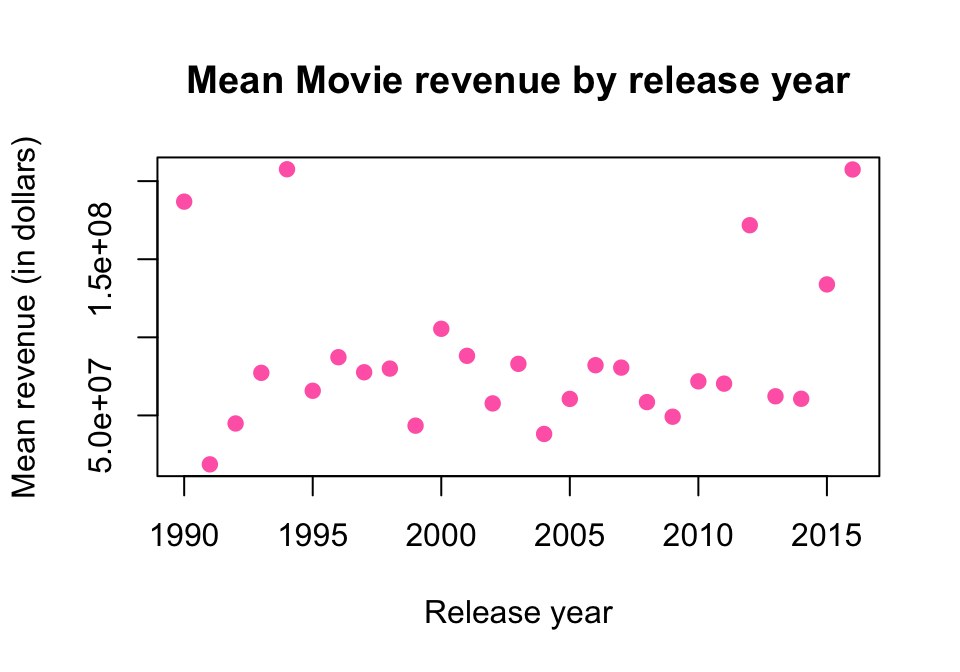

```r
plot(revenue_by_year$release_year, revenue_by_year$revenue,
     main= "Mean Movie revenue by release year",
     xlab= "Release year",
     ylab="Mean revenue (in dollars)",
     pch=19,
     col= "hotpink")
```

**Your Answer:** A scatter plot was created showing the mean revenue per release year and the plot does not show a clear consistent trend of increasing or decreasing over time but fluctuates up and down from year to year. Some of the highest average revenue occur around the 1990s and around 2015 in the dataset, while many of the years in between show lower and more similar average revenues. This shows that the average revenues has not clearly increased over time, and yearly averages appear to be more strongly influenced by a small number of high-or low revenue movies from that specific year than a general industry wide trend.

*step b*

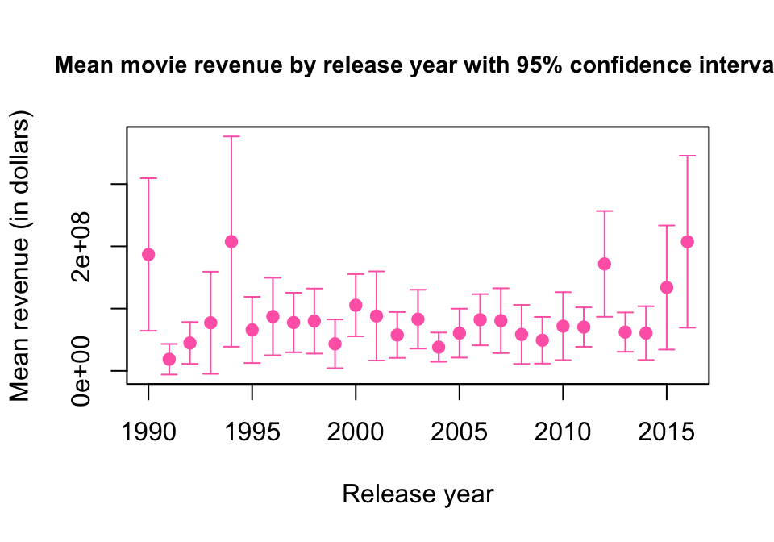

```r
#WRITE YOUR CODE HERE
mean_revenue <- aggregate(revenue ~ release_year, data=movies, FUN=mean)
sd_revenue <- aggregate(revenue ~ release_year, data=movies, FUN=sd)
n_revenue <- aggregate(revenue ~ release_year, data=movies, FUN=length)

se <- sd_revenue$revenue / sqrt(n_revenue$revenue)
lower <- mean_revenue$revenue - 1.96*se
upper <- mean_revenue$revenue + 1.96*se

plot(mean_revenue$release_year, mean_revenue$revenue,
main="Mean movie revenue by release year with 95% confidence interval",
     xlab="Release year",
     ylab="Mean revenue (in dollars)",
     pch=19,
     col="hotpink",
     cex.main=0.9,
     ylim=c(min(lower), max(upper)))

arrows(mean_revenue$release_year, lower,
       mean_revenue$release_year, upper,
       angle=90, code=3, length=0.05, col="hotpink")
```

**Your Answer:** In this scatter plot we create two extra steps on top of our first scatter plot. We calculate the standard deviation and we count the amount of movies per year (in addition to the mean) which lets us calculate the standard error (how uncertain the mean is). After that, we get the upper and lower bounds of the confidence interval, which you can see in the scatter plot (with caps on both sides to make it more clear).

*step c*

```r
#WRITE YOUR CODE HERE
verify <- data.frame(release_year = mean_revenue$release_year,
                      n = n_revenue$revenue,
                      sd = sd_revenue$revenue,
                      ci_width = upper - lower)
verify[order(-verify$ci_width), ]
```

|  | release_year | n | sd | ci_width |
| --- | --- | --- | --- | --- |
| 5 | 1994 | 11 | 285619241 | 337580371 |
| 27 | 2016 | 20 | 315205264 | 276289595 |
| 1 | 1990 | 9 | 187490969 | 244988199 |
| 26 | 2015 | 33 | 292066078 | 199301339 |
| 23 | 2012 | 51 | 309479166 | 169876145 |
| 4 | 1993 | 12 | 144924308 | 163997293 |
| 12 | 2001 | 30 | 199988879 | 143130203 |
| 7 | 1996 | 15 | 122920163 | 124412371 |
| 21 | 2010 | 41 | 178185982 | 109085663 |
| 6 | 1995 | 14 | 101531033 | 106370415 |

[output cut: 17 more lines]

This code creates a table which shows the number of movies, standard deviation of revenue, and the width of the confidence interval for each year, sorted from widest to narrowest. This makes it easy to check whether the years with the widest intervals are also the years with a small sample size and/or a large standard deviation. There are two main reasons why confidence intervals can be wide in a specific year: 1) Small sample size (this leads to a low n): if only a couple of movies were released in a specific year, the mean is based on less data, which makes it less reliable. This could lead to a wider confidence interval. A good example for this reason is year 1990. In this year, n = 9 (relatively small sample size), with a very wide confidence interval: 244988199. This supports the idea that a small sample size leads to a wider interval. 2) High variability in revenue (this leads to a high sd): in a given year, movies can be hits or big flops. This leads to revenue values which are spread far apart. This large spread could also make the confidence interval wider. A good example for this reason is year 2012. In this year, n = 51 (relatively large sample size), which could lead to a small interval. However, the standard deviation is 309479166, and the confidence interval is still 169876145. This shows that high variability in revenue can lead to a wide confidence interval even though the sample size is big.

# Week 4

1. There is an argument going on in the movie studio. *Bob* claims that production budgets are getting out of hand, and that the studio should focus on making cheaper movies. *Chantal* disagrees. She tells Bob that ``Every dollar we spend on movie production is more than offset by the increase in movie revenue’’.
1. Set up a regression model to test Chantal’s claim, and estimate it. That is, estimate:
   $$\text{Revenue}_i=\beta_0+\beta_1 \text{Budget}_i
   +\varepsilon_i.$$
   Print a summary of your estimated model.
2. What is the estimated value of $\beta_1$ and how do you interpet it?
3. Test for the null hypothesis that $\beta_1 \leq 1$. Report the p-value and state your conclusion.
4. Next, estimate the model
   $$\text{Log
   Revenue}_i=\beta_0+\beta_1 \text{Log Budget}_i +\varepsilon_i.$$
   When creating the variables Log Revenue and Log Budget, make sure that movies with a Revenue or Budget of zero are assigned the value “NA”. Print a summary of your estimated model.
5. What is the estimated value of $\beta_1$ and how do you interpet it?
6. Which model has better fit? The level-level model or the log-log model? Explain.
7. Who do you think is correct? Bob or Chantal? What would you advise the movie studio to do?

*step a*

```r
#WRITE YOUR CODE HERE
model1<-lm(revenue ~ budget, data=movies)

summary(model1)
```

```
##
## Call:
## lm(formula = revenue ~ budget, data = movies)
##
## Residuals:
##        Min         1Q     Median         3Q        Max
## -462638759  -35800260    8464473   11626239  835595485
##
## Coefficients:
##               Estimate Std. Error t value Pr(>|t|)
## (Intercept) -1.163e+07  4.708e+06   -2.47   0.0137 *
## budget       3.162e+00  9.104e-02   34.73   <2e-16 ***
## ---
## Signif. codes:  0 '***' 0.001 '**' 0.01 '*' 0.05 '.' 0.1 ' ' 1
##
## Residual standard error: 109300000 on 806 degrees of freedom
## Multiple R-squared:  0.5994, Adjusted R-squared:  0.5989
## F-statistic:  1206 on 1 and 806 DF,  p-value: < 2.2e-16
```

**Your Answer:**

We estimate the model Revenue:
$$\text{Revenue}_i=\beta_0+\beta_1 \text{Budget}_i
+\varepsilon_i.$$

by OLS. The summary of the estimated model consists of the intercept of -1.163e+07, the slope on budget=3.162 and R^2=0.5994

*step b*

**Your Answer:**

The estimated value of β₁ (used from code a) is 3.162, where both variables are measured in dollars. This means that a one-dollars increase in a movie’s budget is associated with an average increase in revenue of $3.16 dollars. The estimate is statistically significant since t=34.73 and p<0.001

*step c*

```r
#WRITE YOUR CODE HERE
b1 <- coef(summary(model1))["budget","Estimate"]
se <- coef(summary(model1))["budget", "Std. Error"]

# H0: beta1 <= 1
t_stat <-(b1-1)/se
t_stat
```

```
## [1] 23.74518
```

```r
#one-sided p-value (right tail)
p_val <-pt(t_stat, df=df.residual(model1),lower.tail=FALSE)
p_val
```

```
## [1] 3.277238e-95
```

**Your Answer:**

Since Chantal claims that every dollar that is spend on production is more than offset by an increase in revenue, which means β₁>1 we test:

H0: β₁<=1

H1: β₁> 1

The t-statistic is t=23.75 with 806 degrees of freedom. The one-sided p-value is 3.28 x 10^-95 which is very close to zero. That’s why we reject H0 since p<0.05, because there is strong statistical evidence that β₁ is larger than 1 and so the data supports Chantal’s claim that an extra dollar of budget is associated with more than one extra dollar of revenue.

*step d*

```r
#WRITE YOUR CODE HERE
#making the log-variables
movies$log_revenue <-ifelse(movies$revenue ==0, NA, log(movies$revenue))
movies$log_budget <- ifelse(movies$budget ==0, NA, log(movies$budget))

model2<-lm(log_revenue ~ log_budget, data=movies)

summary(model2)
```

```
##
## Call:
## lm(formula = log_revenue ~ log_budget, data = movies)
##
## Residuals:
##      Min       1Q   Median       3Q      Max
## -13.6073  -0.6971   0.2294   0.8698   3.8941
##
## Coefficients:
##             Estimate Std. Error t value Pr(>|t|)
## (Intercept) -0.04588    0.77932  -0.059    0.953
## log_budget   1.02996    0.04573  22.523   <2e-16 ***
## ---
## Signif. codes:  0 '***' 0.001 '**' 0.01 '*' 0.05 '.' 0.1 ' ' 1
##
## Residual standard error: 1.495 on 517 degrees of freedom
##   (289 observations deleted due to missingness)
## Multiple R-squared:  0.4953, Adjusted R-squared:  0.4943
## F-statistic: 507.3 on 1 and 517 DF,  p-value: < 2.2e-16
```

**Your Answer:**

We created the variables log_revenue and log_budget, assigning NA to the movies with a revenue or budget of zero. Plus we estimated the log-log model by OLS. The summary of the estimated model is shown above (by summary(model2))

*step e*

```r
#WRITE YOUR CODE HERE
##results used from code from d
```

**Your Answer:**

The estimated value of β₁ is 1.030. This translates to β₁ being an elasticity in a log-log model: a 1% increase in a movie’s budget is associated with an average increase in revenue of 1.03%. The estimate is statistically significant since the t value is 22.52 and p<0.001.

*step f*

```r
#WRITE YOUR CODE HERE
summary(model1)$r.squared
```

```
## [1] 0.5994288
```

```r
summary(model2)$r.squared
```

```
## [1] 0.4952515
```

**Your Answer:**

Based on R² alone, the level-level model seems to fit better (R<sup>2</sup> of 0.599) than the log-log model (R<sup>2</sup> of 0.495). However, these values cannot be compared directly, for two reasons. First, the dependent variables are different (revenue in dollars vs log revenue), so the R<sup>2</sup> values describe the share of variance of two different variables. Second, the log-log model uses fewer observations (519 instead of 808) since movies with zero revenue or budget were dropped and set to NA.

Because the models cannot be compared on R² , we judge them on other ground, and on those we consider the log model more appropriate. It reduces the skewness of the revenue and the influence of extreme values (like the Avengers), and it leaves out the zeros which most likely represent missing data than true zero revenues or budgets. The level-level model does include these zeros which may distort the estimate of β₁. Therefore, we conclude that the log-log model fits better eventough its R² is lower.

*step g*

```r
#WRITE YOUR CODE HERE
##test H0: beta=1 in the log-log model
b1_log<-coef(summary(model2))["log_budget","Estimate"]
se_log<-coef(summary(model2))["log_budget","Std. Error"]
t_log<-(b1_log-1)/se_log
t_log
```

```
## [1] 0.6550588
```

```r
2*pt(abs(t_log),df=df.residual(model2),lower.tail=FALSE)
```

```
## [1] 0.5127212
```

```r
##predicted revenue at average budget ($30 million)
exp(predict(model2,newdata=data.frame(log_budget=log(30000000))))
```

```
##        1
## 47993119
```

**Your Answer:**

We mostly agree with Chantal since in the level-level model (discussed in question c) β₁=3.16 and we would reject H0:β₁<=1. This means that on average every extra dollar of budget goes together with more than one extra dollar of revenue. In the log-log model the elasticity is around 1.03, which is not significantly different from 1 (t=0.66, p=0.51). This shows that revenue rises proportionally with budget. At the average budget of around $30 million the model predicts a revenue of around $48millon, so an extra dollar of budget still goes together with about $1.65 (1.03 x 48/30) of extra revenue. In both models higher budgets do not come with lower revenue. Therefore, Bob’s claim that budgets are “out of hand” is not supported by the data.

However, some caution is needed with this interpretation. First, the models show correlation, not causation. The more expensive movies are often blockbusters with famous actors and larger marketing campaigns which can be a cause for the higher revenue. Second, revenue is not profit: the marketing costs and the share that goes to cinemas is not included. An elasticity of about 1 does mean that bigger budgets give no advantage of scale, so revenue does not grow faster than budget. Third, the average relationship hides large differences between movies, so high-budget movies still carry risk.

Our advice would therefore be not to cut budgets or to focus on cheaper movies, but to evaluate projects on expected profit rather than revenue alone, and to invest in selectively high budget projects.

2

1. Make a scatterplot with log revenue on the y-axis, and log budget on the x-axis. Within the same scatterplot, draw a straight line which summarizes the association between the log of revenue and log of budget.
2. Using the insights from the scatterplot, your linear model, and your data, find an example of a movie that vastly overperformed. That means, find a movie that had much more revenue than expected, given its budget. For this movie, report its log of revenue, its predicted log of revenue, and its residual.

*step a*

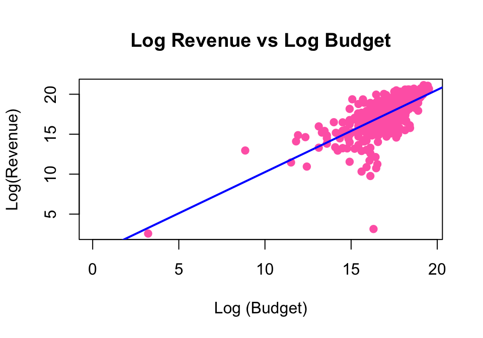

```r
#WRITE YOUR CODE HERE
plot(movies$log_budget,movies$log_revenue,
     main= "Log Revenue vs Log Budget",
     xlab= "Log (Budget)",
     ylab = "Log(Revenue)",
     pch=19,
     col= "hotpink")
abline(model2, col = "blue", lwd = 2)
```

**Your Answer:**

The scatter plot shows a positive and roughly linear association between log budget and log revenue: the movies with a higher budget tend to earn a higher revenue. The blue line is the fitted regression line, with an intercept of -0.05 and a slope of 1.03. This means that a 1% increase of budget is associated with a revenue that is 1.03% higher. The slope is highly significant (p<2e-16). The R-squared is 0.495, so the budget explains half of the variation in log revenue. The points are spread quite widely around the line, which shows that other factors have a influence as well. The model uses 519 movies, because 289 movies with a budget or revenue of zero (NA) were left out.

*step b*

```r
#WRITE YOUR CODE HERE
movies$pred_log_revenue<-predict(model2,newdata=movies)
movies$resid<-movies$log_revenue-movies$pred_log_revenue

print(head(movies[order(-movies$resid),c("title","budget","revenue","log_revenue","pred_log_revenue","resid")],5))
```

```
##                     title  budget   revenue log_revenue pred_log_revenue
## 627        The Full Monty 3.5e+06 257850122    19.36789        15.473776
## 524                Primer 7.0e+03    424760    12.95928         9.073006
## 257             Annabelle 6.5e+06 255273813    19.35785        16.111359
## 623          Pretty Woman 1.4e+07 463000000    19.95324        16.901598
## 762 Paranormal Activity 4 5.0e+06 142817992    18.77708        15.841135
##        resid
## 627 3.894113
## 524 3.886274
## 257 3.246488
## 623 3.051640
## 762 2.935946
```

**Your Answer:**

The movie that over performed is the Full Monty, which had a budget of $3.5 million. The log revenue is 19.37, while the model predicted a log revenue of only 15.47. The residual (19.37-15.47) is 3.89, which means that the actual revenue was about 49 times higher than predicted since its a log-log model (e^3.89≈49). The model expected around $5 million in revenue, but the movie earned around $258 million, which is far more than expected given its budget. Primer has an almost identical residual (3.89) but the prediction is less reliable because of a budget of only $7000. Therefore we chose The Full Monty as the clearest example.

# Week 5

1. Make a frequency table of the variable genre. Which are the three genres that occur the most?
2. Create a new variable called genre2. Make sure that the three most popular genres remain the same, but that all the other genres get categorized into one genre called “Other”. Report a frequency table of this new variable genre2.
3. Estimate an OLS model which has as dependent variable the log of revenue of a movie, and as independent variable the log of budget, a dummy for each level that genre2 can take, and the year of release. Show a summary of the resulting model and interpret each coefficient.

The movie studio that you work at is releasing a new movie in 2026. It will be a Drama movie with a budget of 20,000,0000. It will have a runtime of 120 minutes.

4. Estimate a model that is able to predict the revenue of this movie. Give its predicted revenue and include a 90% prediction interval.
5. Plot the residuals against various independent variables in the model. Do you find any evidence of heteroskedasticity?
6. One executive at the studio wants to time the release of the movie to a specific month of the year such that they can maximize revenue. Another executive is of the opinion that the month in which the movie is released will not have a big impact on its revenue. Estimate a model that can test whether the month of release impacts the revenue of a movie. Use an appropriate hypothesis test to test whether month of release matters. What would you advise the movie studio regarding the timing of the release of the movie?

*step a*

```r
#WRITE YOUR CODE HERE
genre_table <- table(movies$genre)
genre_table_sorted <- sort(genre_table, decreasing = TRUE)
genre_table_sorted
```

```
##
##       Drama      Comedy    Thriller      Action   Adventure      Family
##         402         186         116          41          16          11
##      Horror Documentary     Fiction       Music       Crime     Romance
##          11           9           5           4           2           1
##     Western
##           1
```

**Your Answer:**

The frequency table shows that the three most common genres are drama: 402 movies, comedy: 186 movies and thriller with 116 movies.

*step b*

```r
#WRITE YOUR CODE HERE
top3 <- names(genre_table_sorted)[1:3]
top3
```

```
## [1] "Drama"    "Comedy"   "Thriller"
```

```r
movies$genre2 <- ifelse(movies$genre %in% top3,movies$genre, "Other")
movies$genre2 <- as.factor(movies$genre2)

table(movies$genre2)
```

```
##
##   Comedy    Drama    Other Thriller
##      186      402      104      116
```

**Your Answer:**

The variable genre2 keeps Drama, Comedy and Thriller as separate categories and all the other categories are grouped together under the name “Other”. The table shows 186 movies in Comedy, 402 in Drama, 104 in Other and 116 in Thriller. The total is 808 movies.

*step c*

```r
#WRITE YOUR CODE HERE
movies_clean <- movies[movies$revenue > 0 & movies$budget > 0, ]

movies_clean$log_revenue <- log(movies_clean$revenue)
movies_clean$log_budget <- log(movies_clean$budget)

model <- lm(log_revenue ~ log_budget + genre2 + release_year, data = movies_clean)
summary(model)
```

```
##
## Call:
## lm(formula = log_revenue ~ log_budget + genre2 + release_year,
##     data = movies_clean)
##
## Residuals:
##      Min       1Q   Median       3Q      Max
## -13.5777  -0.6653   0.2248   0.8514   3.8557
##
## Coefficients:
##                 Estimate Std. Error t value Pr(>|t|)
## (Intercept)     9.097982  19.628713   0.464  0.64320
## log_budget      1.001004   0.047074  21.264  < 2e-16 ***
## genre2Drama    -0.472877   0.162469  -2.911  0.00376 **
## genre2Other    -0.014269   0.223589  -0.064  0.94914
## genre2Thriller -0.321644   0.200858  -1.601  0.10991
## release_year   -0.004184   0.009789  -0.427  0.66926
## ---
## Signif. codes:  0 '***' 0.001 '**' 0.01 '*' 0.05 '.' 0.1 ' ' 1
##
## Residual standard error: 1.486 on 513 degrees of freedom
## Multiple R-squared:  0.5053, Adjusted R-squared:  0.5005
## F-statistic: 104.8 on 5 and 513 DF,  p-value: < 2.2e-16
```

```r
levels(movies_clean$genre2)
```

```
## [1] "Comedy"   "Drama"    "Other"    "Thriller"
```

**Your Answer:**

Note that movies with a budget or revenue of zero were excluded, because log() is undefined for these values. This causes the sample to be reduced from 808 to 519 movies.

Comedy is the reference category.

**The estimated model is**: log(revenue) = 9.098 + 1.001*log(budget) - 0.473*genre2Drama - 0.014*genre2Other - 0.322*genre2Thriller - 0.004*release_year

**Our interpretation of each coefficient:**

**Intercept (9.098, not significant)**: the predicted log(revenue) for a Comedy movie when log(budget) and release_year are 0. This is not practically meaningful on its own.

**log(budget) (1.001, p < 0.001)**: this coefficient is highly significant. A 1% increase in budget is associated with an approximately 1% increase in revenue, holding genre and release year constant. This indicates a almost proportional relationship between budget and revenue.

**genre2Drama (-0.473, p = 0.004):** this is significant at the 1% level. Drama movies are predicted to have a log(revenue) that is 0.473 lower than Comedy movies, holding budget and release year constant. This means that on average drama films generate approximately (1 - e^(-0.473)) x 100 % ≈ 37.7 % less revenue than comedy films.

**genre2Other (-0.014, p = 0.949):** This coefficient is not statistically significant. That means that there is no evidence that movies in the “Other” genre category differ from Comedy movies in terms of revenue, holding budget and release year constant.

**genre2Thriller (-0.322, p = 0.110):** not statistically significant at the 5% level. Holding budget and release year constant, there is no strong evidence that Thriller movies differ in revenue compared to Comedy movies.

**release_year (-0.004, p = 0.669):** This coefficient is not statistically significant, there is no evidence that the release is associated with revenue, holding budget and genre constant.

The model has an R squared of 0.505, which means approximately 50.5% of the variation in log(revenue) is explained by budget, release year and genre. The overall model is highly significant. The results show that budget is the strongest predictor of revenue. Genre matters mainly through the Drama category, which is associated with significantly lower revenue, while release year has no meaningful effect.

*step d*

```r
#WRITE YOUR CODE HERE
model_d <- lm(log_revenue ~ log_budget + genre2 + release_year + runtime, data = movies_clean)
summary(model_d)$r.squared
```

```
## [1] 0.5055703
```

```r
new_movie <- data.frame(
  log_budget = log(200000000),
  genre2 = "Drama",
  release_year = 2026,
  runtime = 120
)

pred <- predict(model_d, newdata = new_movie, interval = "prediction", level = 0.90)
exp(pred)
```

```
##         fit      lwr        upr
## 1 234411504 19507130 2816854825
```

**Your Answer:**

For this step we used the model from part C, extended with runtime (120 minutes) and a budget of 200,000,000 (we assume that 20,000,0000 given in the exercise is 200,000,000) for the drama movie released in 2026, and predicted log revenue with predict(), which we transformed back to revenue with exp(). We used a 90% prediction interval. The predicted revenue of the movie is about 234.4 million (234,411,504). The 90% prediction interval ranges from 19.5 million (19,507,130) to 2.82 billion (2,816,854,825). The interval is very wide because the model has an R^2 of 0.5056 and a large residual standard error (1.49 in logs), so movies with the same budget, genre, year and runtime still differ a lot in revenue. Also, a prediction interval is for one single movie, so it includes the random difference of that specific movie. After transforming back with exp(), this results in a very wide interval.

*step e*

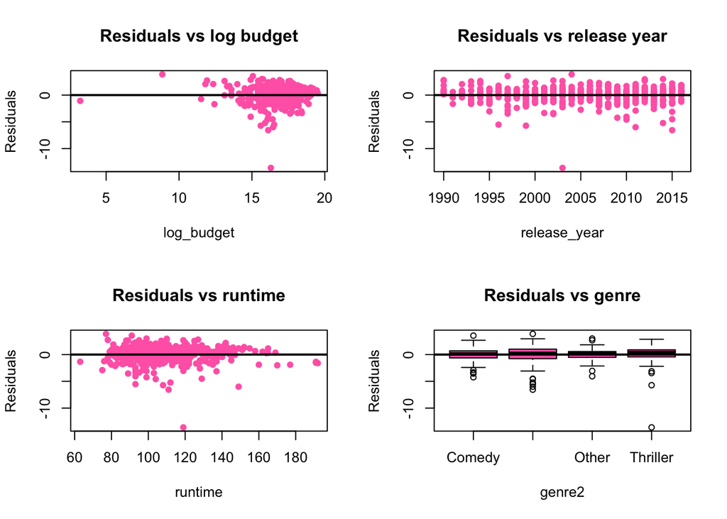

```r
#WRITE YOUR CODE HERE
par(mfrow = c(2, 2))

plot(movies_clean$log_budget, resid(model_d),
     xlab = "log_budget", ylab = "Residuals", main = "Residuals vs log budget",
     pch = 16, col = "hotpink")
abline(h = 0, col = "black", lwd = 2)

plot(movies_clean$release_year, resid(model_d),
     xlab = "release_year", ylab = "Residuals", main = "Residuals vs release year",
     pch = 16, col = "hotpink")
abline(h = 0, col = "black", lwd = 2)

plot(movies_clean$runtime, resid(model_d),
     xlab = "runtime", ylab = "Residuals", main = "Residuals vs runtime",
     pch = 16, col = "hotpink")
abline(h = 0, col = "black", lwd = 2)

boxplot(resid(model_d) ~ movies_clean$genre2,
        xlab = "genre2", ylab = "Residuals", main = "Residuals vs genre",
        col = "hotpink")
abline(h = 0, col = "black", lwd = 2)
```

```r
par(mfrow = c(1, 1))
```

[output not shown]

[output not shown]

```r
anova(model_d, model_f)
```

|  | Res.Df | RSS | Df | Sum of Sq | F | Pr(>F) |
| --- | --- | --- | --- | --- | --- | --- |
| 1 | 512 | 1132.568 | NA | NA | NA | NA |
| 2 | 501 | 1083.083 | 11 | 49.48441 | 2.080902 | 0.02023102 |

For this exercise we added the release month as a categorical variable to the model of part d, so the model now contains log budget, genre, release year, runtime and release month. To test whether the month of release matters, we used an F-test that compares the model with and without month (H0: all month coefficients are 0, H1: at least one month coefficient is different from 0). The test gives F(11, 501) = 2.08, with a p-value of 0.020. Since the p-value is below 0.05, we reject H0 in favor of H1. This means that adding release month significantly improves the model, suggesting that the month of release has a significant effect on revenue. We would advise the studio, regarding the timing of the release of the movie, to release it in November, December or May and to avoid September. We advise these months because they have the highest coefficients, which means that movies released in these months generate more revenue than movies released in January (reference month), holding the other variables constant. September has a negative coefficient, so movies released in September generate less revenue than movies released in January. The column Pct_diff shows the coefficients as a percentage difference in revenue compared to January. For example, a movie released in November earns about 55.8% more revenue than a movie released in January. However, when we look at each month separately, none of the differences is significant at the 5% level, so we cannot conclude with confidence that these are the best or worst months for a movie release.